# TokyoR 68 LT ViewとEnvironment Paneでデータの構造も見てみよう

niszet

2018/03/03

# 自己紹介

## こんな人です

名前：niszet*  
Rおじさん歴：2年目  
趣味：R、楽器(お休み中)、ラズパイなど

普段は回路設計などしています

# Rでデータを視る

## Rでデータを視る…

- 変数名をコンソールに書いてEnter
  - `iris`とか。コンソール上に全部表示されてしまう…
- コンソール上で要約を視る
  - `summary()`, `fivenum()`, `IRQ()`, `skimr::skim()`, …
- データの関係をプロットして視る
  - `plot()`, `hist()`, `ggplot2`, `plotly`, …
- データ（オブジェクト）の構造を視る
  - `str()`, `View()`, `class()`, `attributes()`, `typeof()`, …

## データの構造とは？

- vector
  - 要素はすべて同じ型。2次元なら matrix, 多次元なら array
- data.frame
  - 列ごとに同じ型。行数は全列で同じ
  - これの拡張版?に tibble がある
- list
  - 異なる型と長さのベクトルを要素に持つことが出来る
  - list を要素に持つことも出来、複雑な構造がつくれる
- S3, S4, RC(R5) などのクラス
  - S3はlist構造にclass属性を持たせたもの
- 環境(environment)

…など。今回はlistに注目。

## `str()`でデータの構造を確認する

- `str()`の出力はコンソールに直接表示。
  - 変数に代入できないため`head()`も出来ない。
  - 簡単な構造の変数ならこれでも十分確認できる。

```r
list(a=1:10, b=2, c="b", d=1+3i) %>% str() -> res
```

```
## List of 4
##  $ a: int [1:10] 1 2 3 4 5 6 7 8 9 10
##  $ b: num 2
##  $ c: chr "b"
##  $ d: cplx 1+3i
```

```r
# 何の出力も得られませんでした！
res
```

## 複雑なlist構造は`str()`では見きれない

- 例：repurrrsiveパッケージ  
  Examples of Recursive Lists and Nested or Split Data Frames.

```r
# 画面に収まらない…
str(repurrrsive::gh_users)
```

```
## List of 6
##  $ :List of 30
##   ..$ login              : chr "gaborcsardi"
##   ..$ id                 : int 660288
##   ..$ avatar_url         : chr "https://avatars.githubusercontent.com/u/660288?v=3"
##   ..$ gravatar_id        : chr ""
##   ..$ url                : chr "https://api.github.com/users/gaborcsardi"
##   ..$ html_url           : chr "https://github.com/gaborcsardi"
##   ..$ followers_url      : chr "https://api.github.com/users/gaborcsardi/followers"
##   ..$ following_url      : chr "https://api.github.com/users/gaborcsardi/following{/other_user}"
##   ..$ gists_url          : chr "https://api.github.com/users/gaborcsardi/gists{/gist_id}"
##   ..$ starred_url        : chr "https://api.github.com/users/gaborcsardi/starred{/owner}{/repo}"
##   ..$ subscriptions_url  : chr "https://api.github.com/users/gaborcsardi/subscriptions"
##   ..$ organizations_url  : chr "https://api.github.com/users/gaborcsardi/orgs"
##   ..$ repos_url          : chr "https://api.github.com/users/gaborcsardi/repos"
##   ..$ events_url         : chr "https://api.github.com/users/gaborcsardi/events{/privacy}"
##   ..$ received_events_url: chr "https://api.github.com/users/gaborcsardi/received_events"
##   ..$ type               : chr "User"
##   ..$ site_admin         : logi FALSE
##   ..$ name               : chr "Gabor Csardi"
##   ..$ company            : chr "Mango Solutions, @MangoTheCat "
##   ..$ blog               : chr "http://gaborcsardi.org"
##   ..$ location           : chr "Chippenham, UK"
##   ..$ email              : chr "csardi.gabor@gmail.com"
##   ..$ hireable           : NULL
##   ..$ bio                : NULL
##   ..$ public_repos       : int 52
##   ..$ public_gists       : int 6
##   ..$ followers          : int 303
##   ..$ following          : int 22
##   ..$ created_at         : chr "2011-03-09T17:29:25Z"
##   ..$ updated_at         : chr "2016-10-11T11:05:06Z"
##  $ :List of 30
##   ..$ login              : chr "jennybc"
##   ..$ id                 : int 599454
##   ..$ avatar_url         : chr "https://avatars.githubusercontent.com/u/599454?v=3"
##   ..$ gravatar_id        : chr ""
##   ..$ url                : chr "https://api.github.com/users/jennybc"
##   ..$ html_url           : chr "https://github.com/jennybc"
##   ..$ followers_url      : chr "https://api.github.com/users/jennybc/followers"
```

[output cut: 132 more lines]

```
##   ..$ type               : chr "User"
##   ..$ site_admin         : logi FALSE
##   ..$ name               : chr "Maelle Salmon"
##   ..$ company            : chr "ISGlobal"
##   ..$ blog               : chr "https://masalmon.github.io/"
##   ..$ location           : chr "Barcelona, Spain"
##   ..$ email              : NULL
##   ..$ hireable           : NULL
##   ..$ bio                : chr "I use R for getting, preparing, visualizing and analyzing data mostly about air quality & public health."
##   ..$ public_repos       : int 31
##   ..$ public_gists       : int 0
##   ..$ followers          : int 34
##   ..$ following          : int 38
##   ..$ created_at         : chr "2014-08-05T08:10:04Z"
##   ..$ updated_at         : chr "2016-10-24T09:54:57Z"
```

# RStudio IDEの Environment Paneを使う

## List での表示

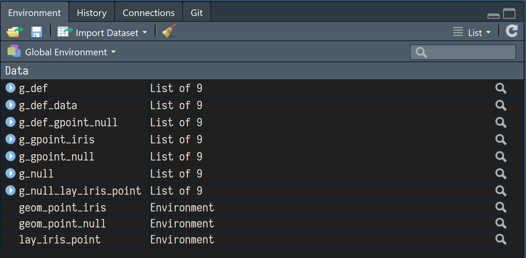

- (>)のアイコンで折り畳み/展開できるので必要な情報だけ詳しく見れる

## List での表示(展開した様子)

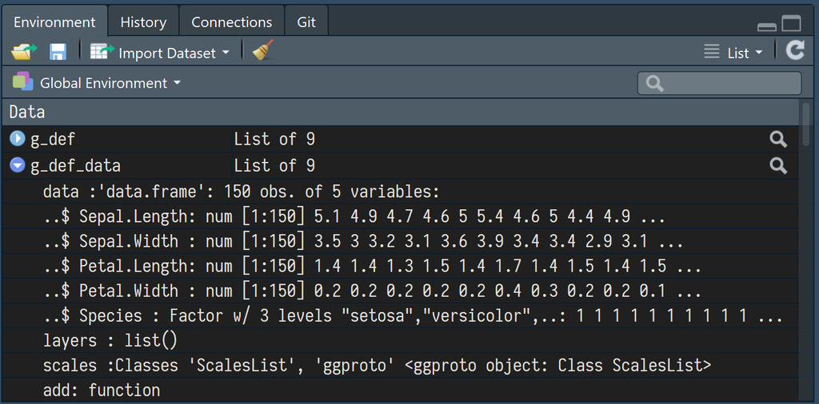

- 展開すると`str()`と同じ表示が得られる
  - ここならば表示してもコンソールが汚れない！

## Grid での表示

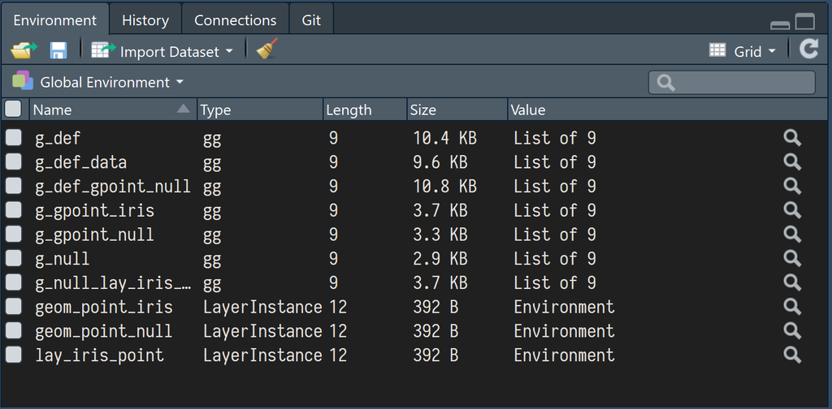

# RStudio IDE 上で `View()` を使ってデータの階層構造を見る

## RStudio IDE v1.1の新機能、 Object Explorer

- RStudio v1.1 – What’s New

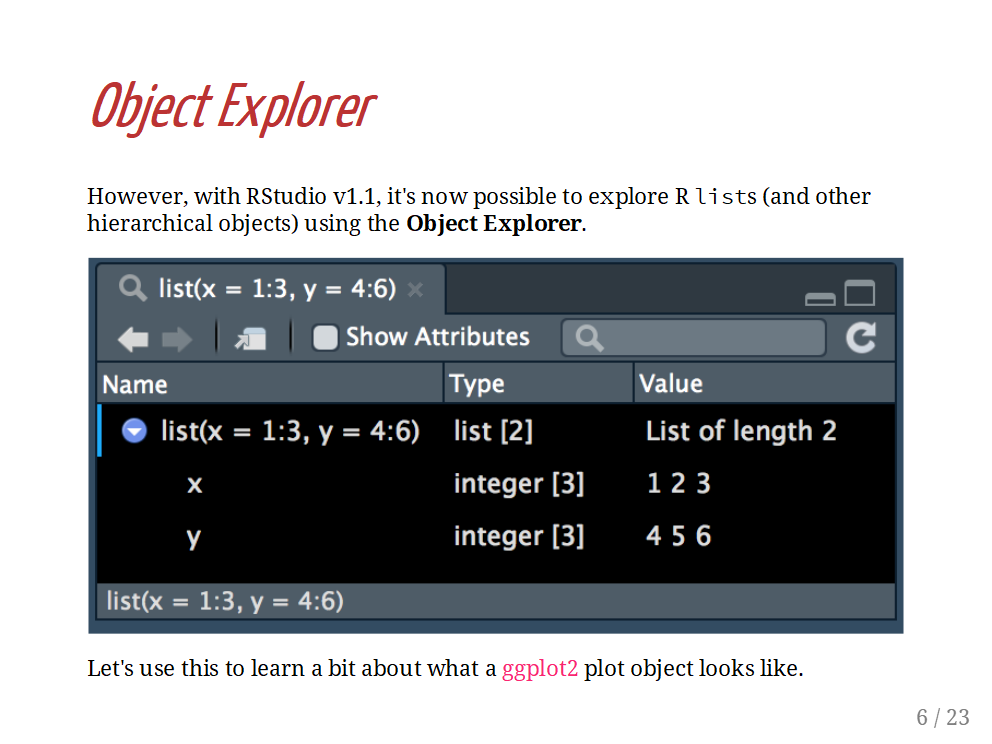

```
https://kevinushey-2018-rstudio-conf.netlify.com/slides.html
```

## `View(repurrrsive::gh_users)`

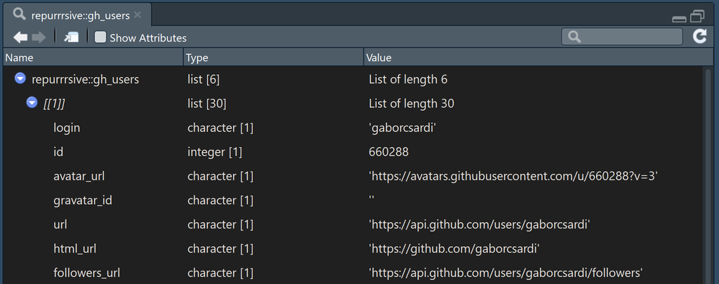

- 階層構造がわかりやすい
  - (>)のアイコンで折りたためるので必要な情報だけに注目できる
- Type（型、クラス）やValue（値）に詳細な情報が載っている

## ggplot2パッケージの場合

kazutanさんの資料を`View()`を使い手を動かしながら  
視ていくとさらにわかりやすい…！

```
https://kazutan.github.io/HijiyamaR6/intro_ggplot2.html
```

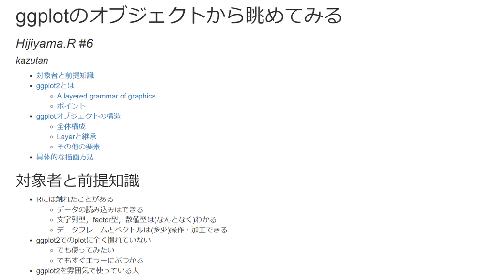

## `ggplot()`にdataを指定した場合

とりあえずいい感じにプロットしてみる

```
g_def_gpoint_null <- ggplot(data = iris, mapping =
           aes(x = Sepal.Length, y = Sepal.Width)) + geom_point()
g_def_gpoint_null
```

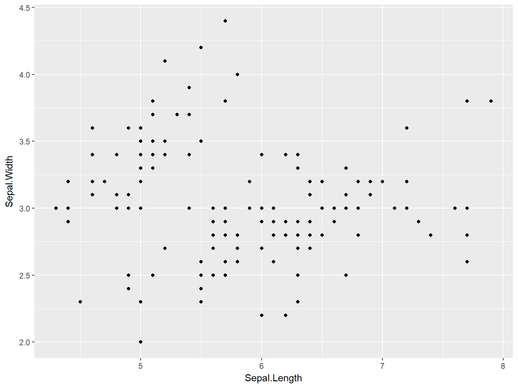

## `View(g_def_gpoint_null)`

- 一番上の階層の `data` に `iris` のデータが入っていることがわかる。
  - `geom_point()`に引数を与えていないので、`layers`の`data`は空

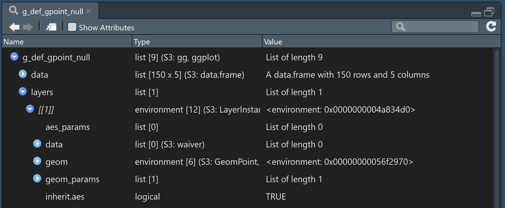

## `geom_point()`にdataを指定した場合

```
g_gpoint_iris <- ggplot() + geom_point(data = iris,
             mapping = aes(x = Sepal.Length, y = Sepal.Width))
g_gpoint_iris
```

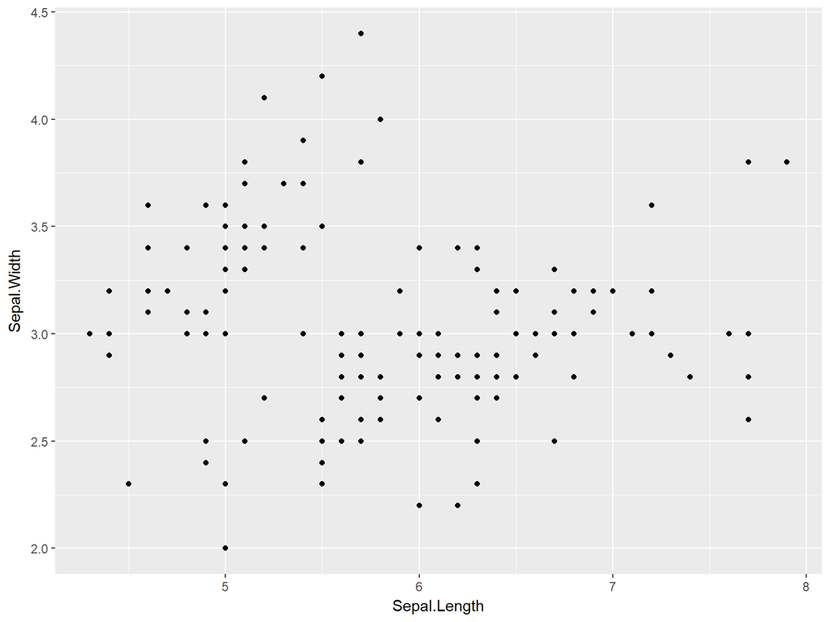

## `View(g_gpoint_iris)`

- `geom_point()`に引数を指定したので、top階層のdataは空
  - irisのデータはlayersの中に入っている
  - plotした図が同じように見えても持っているデータの構造は異なることがわかる

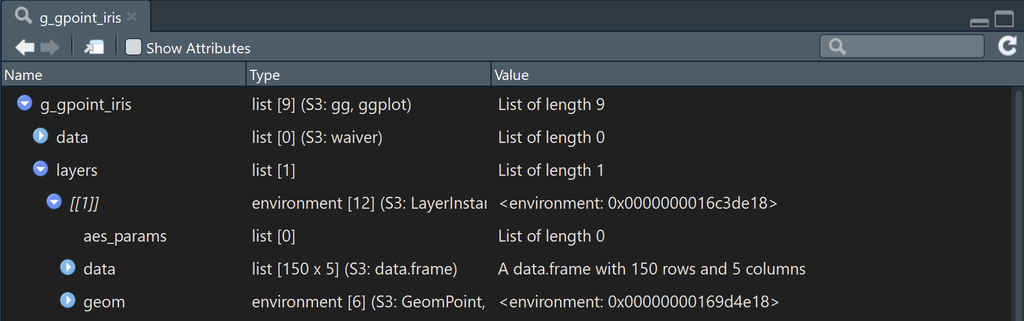

# 注意点

## 細かいことですが…。

- **タブに変数名と異なる名前を与えるとアイコンを押して値を抜き出す方法は使えない**
  - `View(iris, "hoge")` だと`hoge`という変数から値を取ろうとしてしまうため
- list構造のデータは元データが更新されても`View()`で表示させたタブの表示が更新されない。
  - **同じ変数を`View()`で表示するときは先にタブを閉じておくこと**
- data.frameやtibbleは`as.list()`などで変換してから`View()`で表示すれば今回の方法が使える
- このViewの挙動はRStudio IDEで上書きしているため、`utils::View()`のヘルプを見てもわからないので注意。

# まとめ

## データ構造も可視化するぞ…!

- 基本は `str()`
- RStudio IDE の Environment Pane の活用
- `View()`
  - 特に複雑な構造をしている際に、目視で構造を確認できる
  - 折りたためるので情報量を制限できる
  - 詳細な情報が見れる
  - 特定の要素を選択して取り出すことができる
  - `zeallot`でデータを抜き出す際の確認などに。

## 詳細はブログで

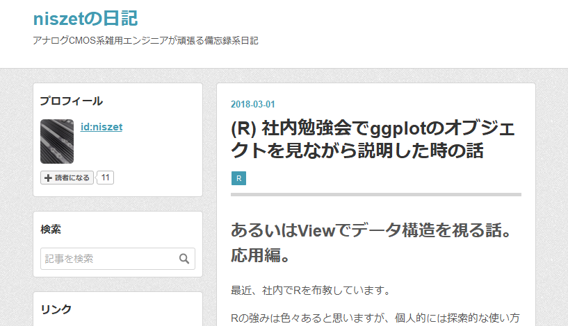

- 今年は40件以上投稿している(R以外の内容も含む)
- 今回の内容の詳細をそれぞれまとめてあります。

## Enjoy!!